# CCLE

The Cancer Cell Line Encyclopedia (CCLE) is a resource of human cancer cell lines by different tissues. Cell lines are collected and made proliferate indefinitely in vitro.

CCLE was developed primarily by the Broad Institute in collaboration with Novartis and others to support cancer biology research and drug discovery.

The cell line study supports large-scale drug screening and genomic studies. The latter is because cells proliferate over time and we can observe a significant genetic drift. However, a key limitation is the absence of the tumor microenvironment. Despite this, CCLE is widely used in cancer research and precision medicine.

## Imports

```python
import pandas as pd
import numpy as np
import matplotlib.pyplot as plt
import seaborn as sns
from sklearn.manifold import TSNE
from scipy.stats import skew, kurtosis
from sklearn.decomposition import PCA
from pandas.plotting import scatter_matrix
from sklearn.preprocessing import StandardScaler
import umap
from combat.pycombat import pycombat
from sklearn.model_selection import train_test_split
import warnings


warnings.filterwarnings('ignore')
```

## Roadmap

In this notebook we will analyse two different cell-lines:

1. Cancer Cell Line (Nature/Broad, 2012) [1]
2. Cancer Cell Line (Broad, 2019) [2]

We obtained expression and mutation data in the cBio Portal by querying CCLE data and then download all the files of the study listed above, more specifically:

1. data_mutations.txt : Dataframe containing information of all the mutated genes in the samples;
2. mut_query.txt: information of all the samples, their study, and the actual mutations;
3. mRNA_data.txt: expression data with samples as columns and genes as rows;

NOTE: for each study the name of the file above is slighty different, we will provide an example of the data

The roadmap we will take for each dataset is the following:

1. Description of the methodology
2. Sample Analysis: analyse QC metrics and filter sample and try to get a grasp of how the data look like
3. Gene Analysis: analyse QC metrics and filter genes and try to get a grasp of how the data look like
4. Dimensionality reduction: plot data in 2 dimensions with various dimensionality reduction techniques and see if data linearly separable or see possible batch effects

Finally, we will prepare data for classification by merging the two datasets by understanding whether some batch effects are present and how to correct them.

### Example data

```python
example_data_mutations = pd.read_csv('/home/3173616/ML_lab/cellline_ccle_broad/data_mutations.txt',
                                      sep = '\t',
                                      comment = '#')
example_data_mutations.head()
```

|  | Hugo_Symbol | Entrez_Gene_Id | Center | NCBI_Build | Chromosome | Start_Position | End_Position | Strand | Consequence | Variant_Classification | ... | Refseq_mRNA_Id | Refseq_prot_Id | SwissProt_acc_Id | SwissProt_entry_Id | Transcript_Strand | UniProt_AApos | UniProt_Region | UniProt_Site | amino_acid_change | cDNA_Change |
| --- | --- | --- | --- | --- | --- | --- | --- | --- | --- | --- | --- | --- | --- | --- | --- | --- | --- | --- | --- | --- | --- |
| 0 | LZIC | 84328.0 | broad.mit.edu | GRCh37 | 1 | 10001236 | 10001239 | + | intron_variant | Intron | ... | NM_032368 | NP_115744 | NaN | NaN | - | NaN | NaN | NaN | NaN | NaN |
| 1 | RTCA | 8634.0 | broad.mit.edu | GRCh37 | 1 | 100731819 | 100731820 | + | 5_prime_UTR_variant | 5'UTR | ... | NM_001130841 | NP_001124313 | NaN | NaN | + | NaN | NaN | NaN | NaN | NaN |
| 2 | CDC14A | 8556.0 | broad.mit.edu | GRCh37 | 1 | 100950184 | 100950184 | + | intron_variant | Intron | ... | NM_033312 | NP_201569 | NaN | NaN | + | NaN | NaN | NaN | NaN | NaN |
| 3 | DFFA | 1676.0 | broad.mit.edu | GRCh37 | 1 | 10521576 | 10521576 | + | missense_variant | Missense_Mutation | ... | NM_004401 | NP_004392 | O00273 | DFFA_HUMAN | - | 323 | NaN | NaN | p.P323S | c.967C>T |
| 4 | DFFA | 1676.0 | broad.mit.edu | GRCh37 | 1 | 10521624 | 10521624 | + | missense_variant | Missense_Mutation | ... | NM_004401 | NP_004392 | O00273 | DFFA_HUMAN | - | 307 | NaN | NaN | p.R307W | c.919C>T |

5 rows × 96 columns

```python
example_mut_query = pd.read_csv('/home/3173616/ML_lab/cellline_ccle_broad/mutations_ccle_2012.txt',
                    sep = '\t',
                    comment = '#')
example_mut_query.head()
```

|  | STUDY_ID | SAMPLE_ID | TP53 |
| --- | --- | --- | --- |
| 0 | cellline_ccle_broad | NCIH1048_LUNG | R273C |
| 1 | cellline_ccle_broad | NCCSTCK140_STOMACH | R248Q |
| 2 | cellline_ccle_broad | NB4_HAEMATOPOIETIC_AND_LYMPHOID_TISSUE | R248Q |
| 3 | cellline_ccle_broad | NB1_AUTONOMIC_GANGLIA | WT |
| 4 | cellline_ccle_broad | NAMALWA_HAEMATOPOIETIC_AND_LYMPHOID_TISSUE | R248Q |

```python
example_mRNA = pd.read_csv('/home/3173616/ML_lab/cellline_ccle_broad/data_mrna_agilent_microarray.txt',
                    sep = '\t',
                    comment = '#')
example_mRNA.head()
```

|  | Hugo_Symbol | Entrez_Gene_Id | 1321N1_CENTRAL_NERVOUS_SYSTEM | 143B_BONE | 22RV1_PROSTATE | 2313287_STOMACH | 42MGBA_CENTRAL_NERVOUS_SYSTEM | 5637_URINARY_TRACT | 59M_OVARY | 639V_URINARY_TRACT | ... | YAPC_PANCREAS | YD10B_UPPER_AERODIGESTIVE_TRACT | YD15_SALIVARY_GLAND | YD38_UPPER_AERODIGESTIVE_TRACT | YD8_UPPER_AERODIGESTIVE_TRACT | YH13_CENTRAL_NERVOUS_SYSTEM | YKG1_CENTRAL_NERVOUS_SYSTEM | YMB1_BREAST | ZR751_BREAST | ZR7530_BREAST |
| --- | --- | --- | --- | --- | --- | --- | --- | --- | --- | --- | --- | --- | --- | --- | --- | --- | --- | --- | --- | --- | --- |
| 0 | ZBTB11-AS1 | 100009676 | 6.138295 | 6.201208 | 6.133910 | 6.623704 | 5.428747 | 6.029951 | 5.326266 | 6.398555 | ... | 5.768004 | 5.539103 | 6.500375 | 5.281651 | 5.066357 | 5.667230 | 5.448129 | 5.687205 | 5.239691 | 5.216891 |
| 1 | AKT3 | 10000 | 8.128408 | 6.602217 | 4.534777 | 4.329897 | 6.648045 | 6.618585 | 5.697945 | 6.170008 | ... | 4.376447 | 5.349740 | 6.759241 | 6.424953 | 6.558525 | 6.910785 | 7.017432 | 4.590385 | 5.864723 | 4.376106 |
| 2 | MED6 | 10001 | 9.791929 | 9.971793 | 8.874570 | 9.115758 | 10.014730 | 9.662901 | 8.879507 | 9.493405 | ... | 8.616445 | 9.144648 | 9.520914 | 9.050495 | 9.839536 | 9.118449 | 8.379130 | 8.578598 | 9.309496 | 9.047250 |
| 3 | NR2E3 | 10002 | 3.757443 | 3.991616 | 3.806170 | 3.676363 | 3.608934 | 4.038367 | 4.100456 | 3.818014 | ... | 3.691457 | 4.312222 | 4.024057 | 4.262051 | 4.024417 | 4.074122 | 3.567282 | 3.879187 | 4.675438 | 4.067023 |
| 4 | NAALAD2 | 10003 | 3.537646 | 3.834468 | 4.045453 | 3.949667 | 4.228992 | 4.173688 | 3.777194 | 3.680178 | ... | 3.547234 | 3.752442 | 3.849795 | 3.862300 | 3.767816 | 3.963852 | 3.796013 | 4.008467 | 3.666915 | 3.872846 |

5 rows × 969 columns

```python
# Free memory
del example_data_mutations, example_mut_query, example_mRNA
```

## Utils

```python
def plot_violin_metrics(data, axis):
    """
    Input:
        data (pd.Dataframe): gene expression matrix, rows are genes and samples are columns
        axis (int): 0 samples, 1 genes
    Output:
        Plot violin plot samples/genes wide
    """

    if axis == 1:

        # Total expression
        total_counts_genes = data.sum(axis=1).reset_index(drop=True)
        # Mean expression
        mean_values_genes = data.mean(axis=1).reset_index(drop=True)
        # Median expression
        median_values_genes = data.median(axis=1).reset_index(drop=True)
        # Standard deviation of expression
        std_values_genes = data.std(axis = 1).reset_index(drop = True)
        # Coefficient of variation of expression
        cv_values_genes = std_values_genes /mean_values_genes
        # Number of non-zero element
        total_features_genes = data.astype(bool).sum(axis = 1).reset_index(drop = True)

        # Set up subplots
        fig, ax = plt.subplots(1, 6, figsize=(25, 12))

        # Total Counts per Gene
        sns.violinplot(y=total_counts_genes, ax=ax[0], color='firebrick')
        ax[0].set_title('Total Counts Across Genes')
        ax[0].set_xlabel('')
        ax[0].grid(True)

        # Mean Counts per Gene
        sns.violinplot(y=mean_values_genes, ax=ax[1], color='steelblue')
        ax[1].set_title('Mean Counts Across Genes')
        ax[1].set_xlabel('')
        ax[1].grid(True)

        # Median Counts per Gene
        sns.violinplot(y=median_values_genes, ax=ax[2], color='orange')
        ax[2].set_title('Median Counts Across Genes')
        ax[2].set_xlabel('')
        ax[2].grid(True)

        # Std values per Gene
        sns.violinplot(y=std_values_genes, ax=ax[3], color='darkgreen')
        ax[3].set_title('Standard deviation across Genes')
        ax[3].set_xlabel('')
        ax[3].grid(True)

        # Coefficeint of variation std/mean per Gene
        sns.violinplot(y=cv_values_genes, ax=ax[4], color='indigo')
        ax[4].set_title('Coefficient of variation across Genes')
        ax[4].set_xlabel('')
        ax[4].grid(True)

        # Total Features per Gene
        sns.violinplot(y=total_features_genes, ax=ax[5], color='silver')
        ax[5].set_title('Total Features Across Genes')
        ax[5].set_xlabel('')
        ax[5].grid(True)

        plt.tight_layout()
        plt.show()

        # Print differences between extremes
        print(f'Max_total_count ({total_counts_genes.max()}) - Min_total_count ({total_counts_genes.min()}) = {total_counts_genes.max() - total_counts_genes.min()}')
        print(f'Max_mean_count ({mean_values_genes.max()}) - Min_mean_count ({mean_values_genes.min()}) = {mean_values_genes.max() - mean_values_genes.min()}')
        print(f'Max_median_count ({median_values_genes.max()}) - Min_median_count ({median_values_genes.min()}) = {median_values_genes.max() - median_values_genes.min()}')
        print(f'Max std  ({std_values_genes.max()}) - Min std ({std_values_genes.min()}) = {std_values_genes.max() - std_values_genes.min()}')
        print(f'Max cv  ({cv_values_genes.max()}) - Min cv ({cv_values_genes.min()}) = {cv_values_genes.max() - cv_values_genes.min()}')
        print(f'Max feature count  ({total_features_genes.max()}) - Min feature count ({total_features_genes.min()}) = {total_features_genes.max() - total_features_genes.min()}')


    if axis == 0:

        total_counts = data.sum(axis=0).reset_index(drop=True)
        mean_values = data.mean(axis=0).reset_index(drop=True)
        std_values = data.std(axis = 0).reset_index(drop=True)
        median_values = data.median(axis=0).reset_index(drop=True)
        cv_values = std_values/mean_values
        total_features = data.astype(bool).sum(axis = 0).reset_index(drop = True)


        # Set up the figure with 3 subplots
        fig, ax = plt.subplots(1, 6, figsize=(25, 12))

        # Total Counts
        sns.violinplot(y=total_counts, ax=ax[0], color='firebrick')
        ax[0].set_title('Total Counts Across Samples')
        ax[0].set_xlabel('')
        ax[0].grid(True)

        # Mean Values
        sns.violinplot(y=mean_values, ax=ax[1], color='steelblue')
        ax[1].set_title('Mean Across Samples')
        ax[1].set_xlabel('')
        ax[1].grid(True)

        # Median Values
        sns.violinplot(y=median_values, ax=ax[2], color='orange')
        ax[2].set_title('Median Samples')
        ax[2].set_xlabel('')
        ax[2].grid(True)

        # Std values
        sns.violinplot(y=std_values, ax=ax[3], color='darkgreen')
        ax[3].set_title('Standard deviation Samples')
        ax[3].set_xlabel('')
        ax[3].grid(True)

        # Coefficeint of variation std/mean per sample
        sns.violinplot(y=cv_values, ax=ax[4], color='indigo')
        ax[4].set_title('Coefficient of variation across Samples')
        ax[4].set_xlabel('')
        ax[4].grid(True)

        # Total features
        sns.violinplot(y=total_features, ax=ax[5], color='silver')
        ax[5].set_title('Total features across Samples')
        ax[5].set_xlabel('')
        ax[5].grid(True)


        plt.tight_layout()
        plt.show()

        # Print differences between extremes
        print(f'Max_total_count ({total_counts.max()}) - Min_total_count ({total_counts.min()}) = {total_counts.max() - total_counts.min()}')
        print(f'Max_mean_count ({mean_values.max()}) - Min_mean_count ({mean_values.min()}) = {mean_values.max() - mean_values.min()}')
        print(f'Max_median_count ({median_values.max()}) - Min_median_count ({median_values.min()}) = {median_values.max() - median_values.min()}')
        print(f'Max_std ({std_values.max()}) - Min_std ({std_values.min()}) = {std_values.max() - std_values.min()}')
        print(f'Max CV ({cv_values.max()}) - Min CV ({cv_values.min()}) = {cv_values.max() - cv_values.min()}')
        print(f'Max feature count  ({total_features.max()}) - Min feature count ({total_features.min()}) = {total_features.max() - total_features.min()}')


def plot_skewness_kurtosis(data,axis):

    """
    Input:
        data (pd.Dataframe): gene expression matrix, rows are genes and samples are columns
        axis (int): 0 samples, 1 genes
    Output:
        Plot skewness, kurtosis plot samples/genes wide
    """


    if axis == 0:
        # Skewness
        skewness_per_sample = data.apply(skew, axis=0)
        # Kurtosis
        kurtosis_per_sample = data.apply(kurtosis, axis=0)

        # Plot skewness
        plt.figure(figsize=(14, 5))
        plt.subplot(1, 2, 1)
        plt.bar(range(len(skewness_per_sample)), skewness_per_sample.values, color='mediumpurple')
        plt.title("Skewness of Expression per Sample")
        plt.xlabel("Sample Index")
        plt.ylabel("Skewness")
        plt.grid(True)

        # Plot kurtosis
        plt.subplot(1, 2, 2)
        plt.bar(range(len(kurtosis_per_sample)), kurtosis_per_sample.values, color='darkorange')
        plt.title("Excess Kurtosis per Sample")
        plt.xlabel("Sample Index")
        plt.ylabel("Kurtosis")
        plt.grid(True)

        plt.tight_layout()
        plt.show()

    if axis == 1:
        # Compute skewness and kurtosis per sample (column-wise)
        skewness_per_gene = data.apply(skew, axis=1)
        kurtosis_per_gene = data.apply(kurtosis, axis=1)

        # Plot skewness
        plt.figure(figsize=(14, 5))
        plt.subplot(1, 2, 1)
        plt.bar(range(len(skewness_per_gene)), skewness_per_gene.values, color='mediumpurple')
        plt.title("Skewness of Expression per Gene")
        plt.xlabel("Sample Index")
        plt.ylabel("Skewness")
        plt.grid(True)

        # Plot kurtosis
        plt.subplot(1, 2, 2)
        plt.bar(range(len(kurtosis_per_gene)), kurtosis_per_gene.values, color='darkorange')
        plt.title("Excess Kurtosis per Gene")
        plt.xlabel("Sample Index")
        plt.ylabel("Kurtosis")
        plt.grid(True)

        plt.tight_layout()
        plt.show()

def heatmap_plot(title,data,samples):
    """
    Input:
        title (str): Title of our plot
        data (pd.Dataframe): gene expression matrix, rows are genes and samples are columns
        samples (list or np.array): subsample to plot the heatmap on
    Output:
        Pearson correlation heatmap between samples
    """
    plt.title(title)
    sns.heatmap(data.loc[:, samples].corr(), cmap = 'viridis', fmt ='.01f');
    print(f"Number of samples plotted: {(len(samples),len(samples))}")


def plot_PCA_tsne_umap(data_ordered, mutated_samples, non_mutated_samples, title, categories):
    """
    Generates a combined plot of PCA, t-SNE, and UMAP visualizations for given data.

    Parameters:
    - data_ordered: pandas DataFrame or array-like, features x samples matrix
    - mutated_samples: list of sample identifiers for mutated samples
    - non_mutated_samples: list of sample identifiers for non-mutated samples
    - title: str, overall title for the figure
    - categories: tuple of two strings (mutated_label, non_mutated_label)
    """
    # Build labels and colors
    mutation_status = [categories[0]] * len(mutated_samples) + [categories[1]] * len(non_mutated_samples)
    label_map = {categories[0]: 0, categories[1]: 1}
    color_values = [label_map[label] for label in mutation_status]

    # Convert data: transpose to samples x features
    X = data_ordered.T.to_numpy()

    # PCA
    pca = PCA(n_components=2, random_state=42)
    pca_result = pca.fit_transform(X)

    # t-SNE
    tsne = TSNE(n_components=2, random_state=42, learning_rate='auto', init='random')
    tsne_result = tsne.fit_transform(X)

    # UMAP
    reducer = umap.UMAP(n_components=2, random_state=42)
    umap_result = reducer.fit_transform(X)

    # Plotting
    plt.figure(figsize=(18, 5))

    # PCA subplot
    plt.subplot(1, 3, 1)
    plt.scatter(pca_result[:, 0], pca_result[:, 1], c=color_values, cmap='viridis', alpha=0.8)
    plt.title('PCA: {} vs {}'.format(categories[0], categories[1]))
    plt.xlabel(f'PC1 ({pca.explained_variance_ratio_[0]*100:.1f}%)')
    plt.ylabel(f'PC2 ({pca.explained_variance_ratio_[1]*100:.1f}%)')
    plt.grid(True)

    # t-SNE subplot
    plt.subplot(1, 3, 2)
    plt.scatter(tsne_result[:, 0], tsne_result[:, 1], c=color_values, cmap='viridis', alpha=0.8)
    plt.title('t-SNE: {} vs {}'.format(categories[0], categories[1]))
    plt.xlabel('tSNE1')
    plt.ylabel('tSNE2')
    plt.grid(True)

    # UMAP subplot
    plt.subplot(1, 3, 3)
    plt.scatter(umap_result[:, 0], umap_result[:, 1], c=color_values, cmap='viridis', alpha=0.8)
    plt.title('UMAP: {} vs {}'.format(categories[0], categories[1]))
    plt.xlabel('UMAP1')
    plt.ylabel('UMAP2')
    plt.grid(True)

    # Legend and overall title
    handles = [plt.Line2D([], [], marker='o', linestyle='', color=plt.cm.viridis(label_map[c]/1), label=c)
               for c in categories]
    plt.legend(handles=handles, title='Category', loc='upper right')
    plt.suptitle(title)
    plt.tight_layout()
    plt.show()


def standard(df):
    """
    Input:
        df (pandas.dataframe): dataframe rows genes and columns samples.

    Output:
        dt (pd.dataframe): data after standardization of the samples.

    """
    dt = df.copy()
    #dt = dt.astype("float64")
    # function for data standardization
    cell_names = dt.columns
    gene_names = dt.index

    scaler = StandardScaler()
    scaler.fit(dt)
    dt = scaler.transform(dt)

    dt = pd.DataFrame(dt)
    dt.index = gene_names
    dt.columns = cell_names

    return(dt)
```

## CCLE 2012

### Description

These data have been obtained using Affymetrix microarray technology. The process is the same as usual sequencing techniques until the mapping from mRNA to cDNA. Afterwards, in order to measure the gene expression, microarray chips are used. These chips have milions of tiny spot (probes), each with short DNA sequences, complementary to known genes. Each gene has multiple probes, which either represent a perfect match or a mismatch to account for some kind of mutations. Then, flouresecent dye is applied at each probe, more colorful probes means higher expression. The latter is measured with laser technology and then corrected for background noise.

### Data imports

```python
# ---------mRNA---------
# Description:
# Expression Data with gene as index and cells/samples as columns
mRNA_2012 = pd.read_csv('/home/3173616/ML_lab/cellline_ccle_broad/data_mrna_agilent_microarray.txt',
                    sep = '\t',
                    comment = '#')
mRNA_2012.set_index('Hugo_Symbol',inplace=True)
# Remove gene id and keep Hugo_Symbol
mRNA_2012 = mRNA_2012[mRNA_2012.columns[1:]]
# Merge with mean the duplicated rows
mRNA_2012 = mRNA_2012.groupby(mRNA_2012.index).mean()


#--------Mut query----------
# Description:
# Data telling  which sample is mutated and not-mutated
mut_query_2012= pd.read_csv('/home/3173616/ML_lab/cellline_ccle_broad/mutations_ccle_2012.txt',
                    sep = '\t',
                    comment = '#')
mut_query_2012.set_index('SAMPLE_ID',inplace=True)

# ------Mut ALL-----------
# Dataset containing mutation classes for all genes, it only contains mutated samples
mut_all_2012 = pd.read_csv('/home/3173616/ML_lab/cellline_ccle_broad/data_mutations.txt',
                    sep = '\t',
                    comment = '#')
# Extract TP53 from all mutated genes
mut_all_2012 = mut_all_2012[mut_all_2012['Hugo_Symbol'] == 'TP53']
# Remove unwanted information
mut_all_2012 = mut_all_2012[['Tumor_Sample_Barcode', 'Variant_Type']]
mut_all_2012.set_index('Tumor_Sample_Barcode', inplace=True)
# There are repetitions of my mutation type (Variant_Type)
# if there is the same sample with different Variant_Type it should be removed
variant_check = mut_all_2012.groupby(mut_all_2012.index)["Variant_Type"].nunique()

# Consistent mutations
non_consistent_indices = variant_check[variant_check != 1].index
consistent_indices = variant_check[variant_check == 1].index

# Filter
mut_all_2012 = mut_all_2012.loc[consistent_indices]
mRNA_2012 = mRNA_2012.drop(columns=[col for col in non_consistent_indices if col in mRNA_2012.columns])
mut_query_2012 = mut_query_2012.drop(index = [idx for idx in non_consistent_indices if idx in mut_query_2012.index])

# There are duplicated samples with same Variant Classification
# since it is the same sample just remove the rest and keep one
mut_all_2012 = mut_all_2012[~mut_all_2012.index.duplicated(keep='first')]
# Merged mutated samples
merged_2012 = mut_query_2012.join(mut_all_2012, how = 'left').fillna('WT')
# Free some memory
del mut_all_2012, mut_query_2012, variant_check, consistent_indices


# Take common samples
common = list(set(mRNA_2012.columns) & set(merged_2012.index))
mRNA_2012 = mRNA_2012[common]
merged_2012 = merged_2012.loc[common]
```

```python
# Rename columns putting study id
mRNA_2012.rename(columns={i:i + '_cellline_ccle_broad' for i in mRNA_2012.columns},inplace=True)
merged_2012.rename(index={i:i + '_cellline_ccle_broad' for i in merged_2012.index},inplace=True)
```

### Sample analysis

```python
# Shape of mRNA
print(f'Number of genes: {len(mRNA_2012.index)}\nNumber of samples: {len(mRNA_2012.columns)}')
print(f'Zero entries: {(mRNA_2012 <= 0).sum().sum()}') # entries all positive no zeros
```

```
Number of genes: 16216
Number of samples: 961
Zero entries: 0
```

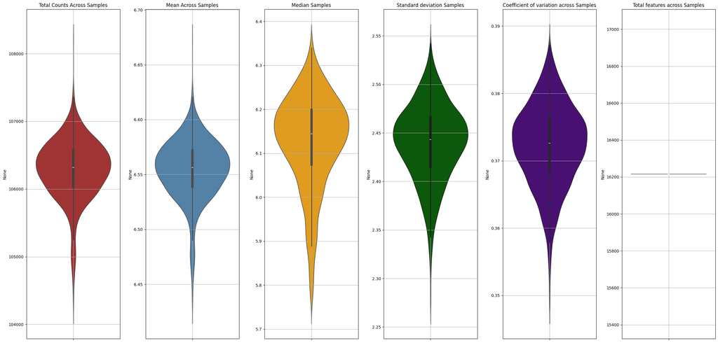

```
Max_total_count (108205.20151000045) - Min_total_count (104237.92892699984) = 3967.2725830006093
Max_mean_count (6.6727430630242015) - Min_mean_count (6.428091325049325) = 0.24465173797487694
Max_median_count (6.3399255) - Min_median_count (5.76591) = 0.5740154999999998
Max_std (2.5418355492174785) - Min_std (2.2733997462706688) = 0.2684358029468097
Max CV (0.3872059578056293) - Min CV (0.34884491132636614) = 0.03836104647926314
Max feature count  (16216) - Min feature count (16216) = 0
```

```python
# Violin plots of many QC metrics
plot_violin_metrics(mRNA_2012,axis = 0)
```

From the distribution of the Quality Control (QC) violin plots, we can observe how the data is very well concetrated and there is no visible presence of an outlier. We did not filter any sample from it.

```python
corr_matrix_micro = mRNA_2012.corr()
```

```python
print('-----Microarray matrix-----')
print('Minimum correlation between samples:',corr_matrix_micro.describe().loc['min'].min())
print('Minimum mean correlation between samples:',corr_matrix_micro.describe().loc['mean'].min())
```

```
-----Microarray matrix-----
Minimum correlation between samples: 0.7008219316913393
Minimum mean correlation between samples: 0.7835038494767922
```

We can observe that linear correlation is very high, a minimum of 0.7 is very high. Samples seem very correlated.

Now let us understand whether there are visual clues about mutated and non mutated samples

```python
# Extract mutated samples
mutated_samples = merged_2012[merged_2012['Variant_Type'] != 'WT'].index
non_mutated_samples = merged_2012[merged_2012['Variant_Type'] == 'WT'].index

# Extract random samples
random_samples_mut_100 = np.random.choice(mutated_samples,size = 100)
random_samples_non_mut_100 = np.random.choice(non_mutated_samples,size = 100)
random_samples_mut_50_non_mut50 = list(random_samples_mut_100[:50]) + list(random_samples_non_mut_100[:50])
```

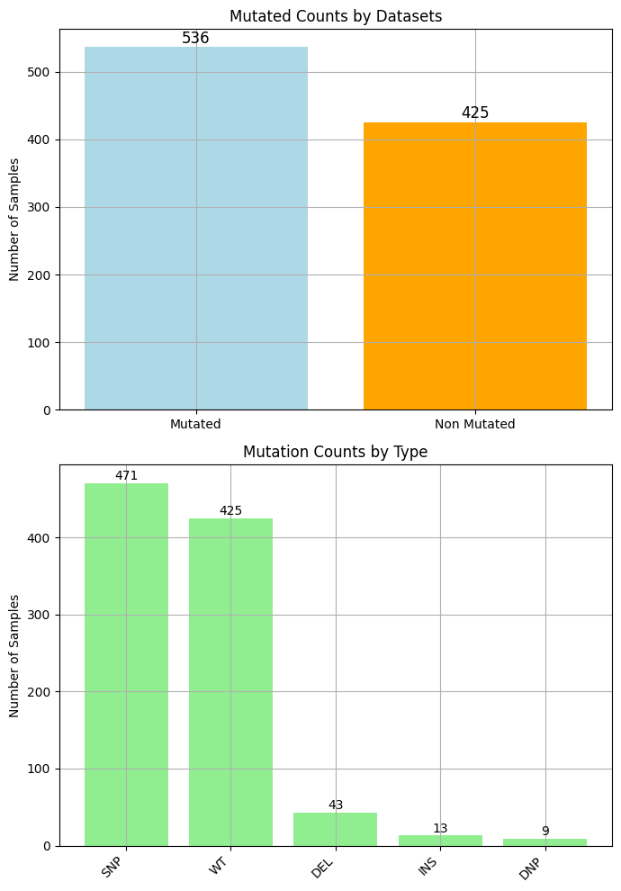

```python
# Sample counts
counts = [len(mutated_samples), len(non_mutated_samples)]

# Create subplots
fig, axs = plt.subplots(2, 1, figsize=(7, 10))

# ---- Plot 1: Sample Counts by Dataset ----
axs[0].bar(x=['Mutated', 'Non Mutated'], height=counts, color=['lightblue', 'orange'])
for i, count in enumerate(counts):
    axs[0].text(i, count + 1, str(count), ha='center', va='bottom', fontsize=12)

axs[0].set_title("Mutated Counts by Datasets")
axs[0].set_ylabel("Number of Samples")
axs[0].grid(True)

# ---- Plot 2: Mutation Counts ----
mut = merged_2012.Variant_Type.value_counts()
axs[1].bar(mut.index, mut.values, color='lightgreen')
for i, val in enumerate(mut.values):
    axs[1].text(i, val + 1, str(val), ha='center', va='bottom', fontsize=10)

axs[1].set_title("Mutation Counts by Type")
axs[1].set_ylabel("Number of Samples")
axs[1].set_xticklabels(mut.index, rotation=45, ha='right')
axs[1].grid(True)

# Adjust layout
plt.tight_layout()
plt.show()
```

For the binary classification, mutated and non-mutated data are balanced. We cannot say the same for multiclass case. Let us analyse now deeply the samples and try to see if we can find correlation in them.

```
Number of samples plotted: (100, 100)
```

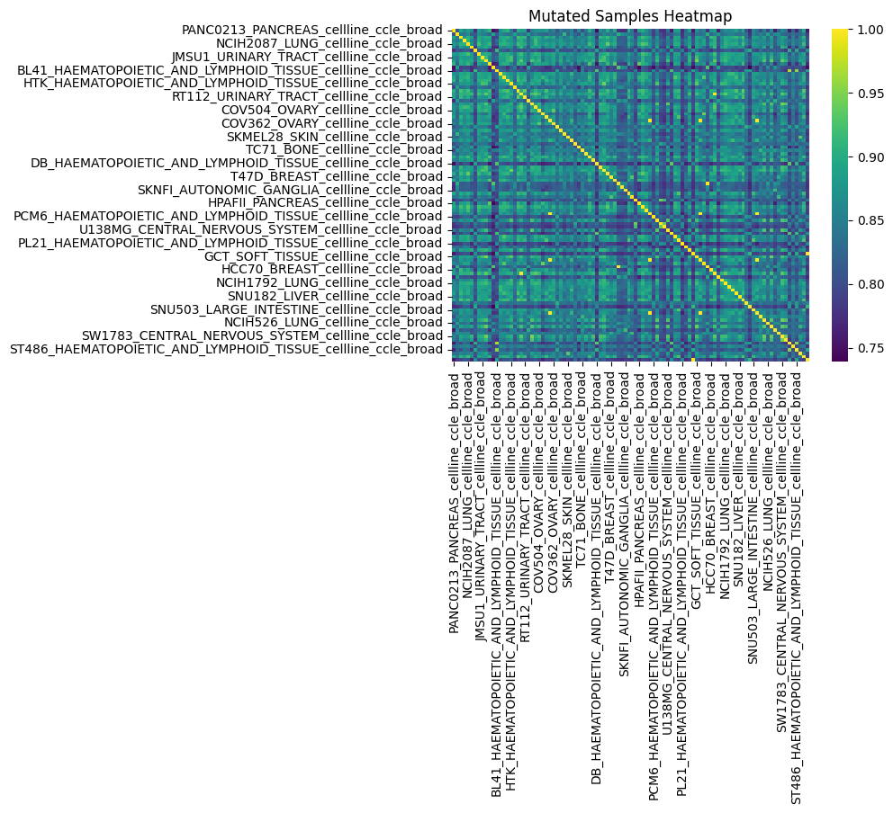

```python
heatmap_plot(title = 'Mutated Samples Heatmap',data=mRNA_2012,samples = random_samples_mut_100)
```

```
Number of samples plotted: (100, 100)
```

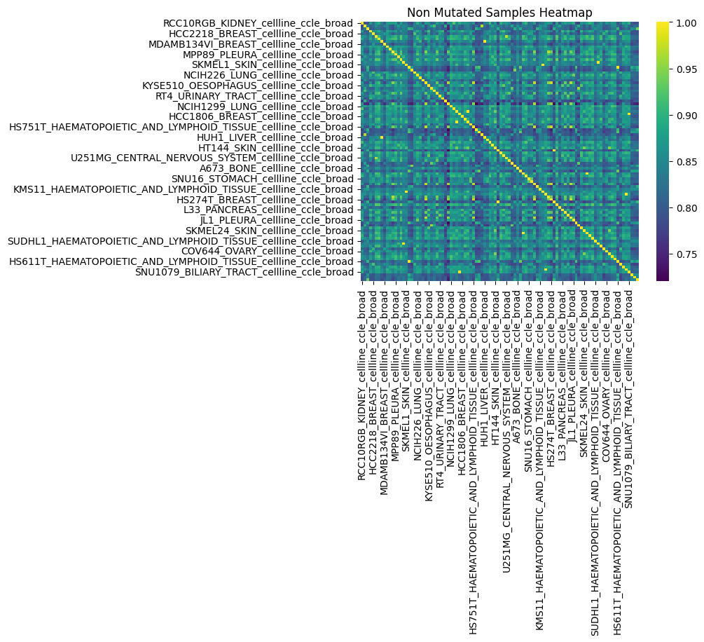

```python
heatmap_plot(title = 'Non Mutated Samples Heatmap',data=mRNA_2012,samples = random_samples_non_mut_100)
```

```
Number of samples plotted: (100, 100)
```

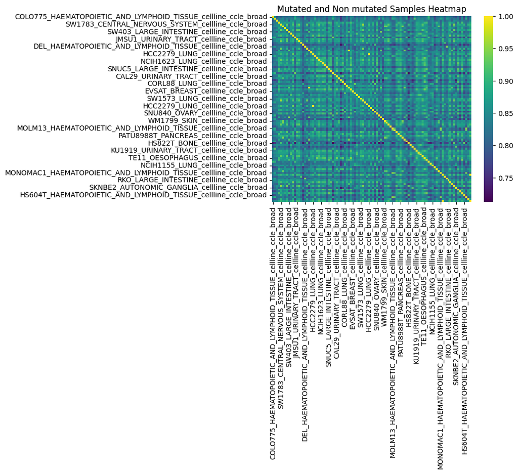

```python
heatmap_plot(title = 'Mutated and Non mutated Samples Heatmap',data=mRNA_2012,samples = random_samples_mut_50_non_mut50)
```

Unfortunately, we cannot observe visual relveant patterns in the heatmap. Despite high correlation in general, differences between mutated and non-mutated seem not present.

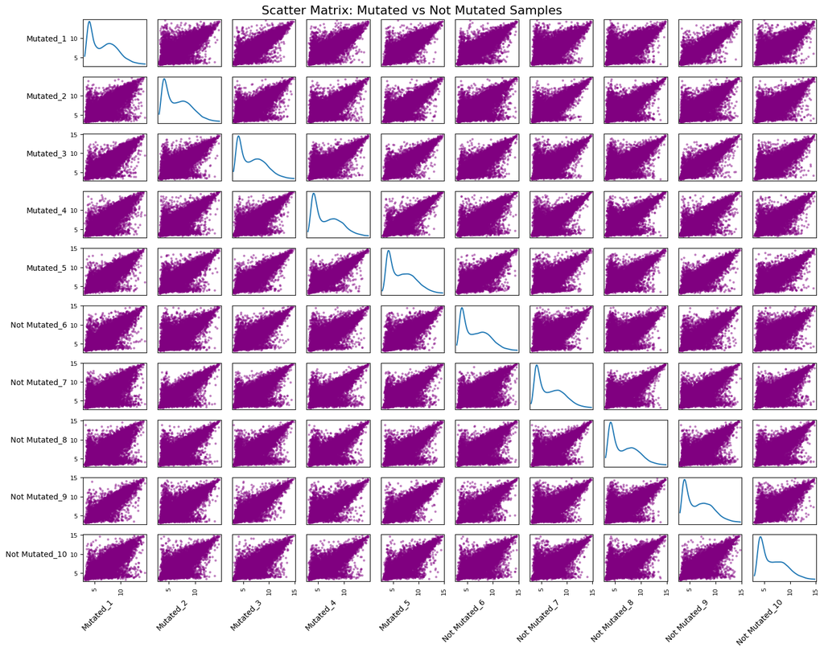

```python
sample_ids = random_samples_mut_100[:5].tolist() + random_samples_non_mut_100[:5].tolist()
sample_mut_non_mut = mRNA_2012.loc[:, sample_ids]

# Rename columns to clearer labels
new_labels = ['Mutated'] * 5 + ['Not Mutated'] * 5
sample_mut_non_mut.columns = [f"{label}_{i+1}" for i, label in enumerate(new_labels)]
axes = scatter_matrix(sample_mut_non_mut, diagonal='kde', figsize=(15, 12), color='purple')

# Rotate x and y axis labels for all subplots
for ax in axes.ravel():
    if ax is not None:
        ax.set_xlabel(ax.get_xlabel(), rotation=45, ha='right')
        ax.set_ylabel(ax.get_ylabel(), rotation=0, ha='right')

plt.suptitle("Scatter Matrix: Mutated vs Not Mutated Samples", fontsize=16)
plt.tight_layout()
plt.show()
```

We can observe that distributions seems to follow a double peaked trend. Both in mutated and non mutated and between themselves.

```python
#-----Mutated samples-----------
print('----Mutated Samples-----')
print('1) Minimum correlation between samples:',mRNA_2012.loc[:, mutated_samples].corr().describe().loc['min'].min())
print('2) Minimum mean correlation between samples:',mRNA_2012.loc[:, mutated_samples].corr().describe().loc['mean'].min())
#----- Non Mutated samples-----------
print('----Non Mutated Samples-------')
print('1) Minimum correlation between samples:',mRNA_2012.loc[:, non_mutated_samples].corr().describe().loc['min'].min())
print('2) Minimum mean correlation between samples:',mRNA_2012.loc[:, non_mutated_samples].corr().describe().loc['mean'].min())
```

```
----Mutated Samples-----
```

```
1) Minimum correlation between samples: 0.7084520522344295
2) Minimum mean correlation between samples: 0.7924987621910312
----Non Mutated Samples-------
1) Minimum correlation between samples: 0.7126124003704839
2) Minimum mean correlation between samples: 0.7798416510839231
```

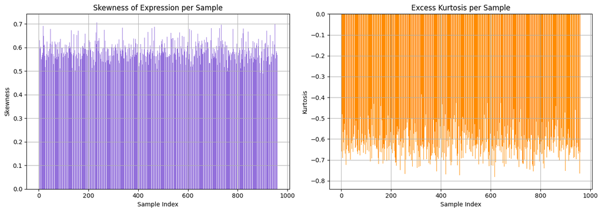

```python
plot_skewness_kurtosis(data=mRNA_2012,axis = 0)
```

The skewness and kurtosis measures are commonly utlilized to assess the normality of a distribution. Skweness quantifies the symmetry of the data distribution, while kurtosis measures the thickness of the tails.

There are three types of skewness:

1. **Zero**:the skewness is zero when the distributiom is exactly normal;
2. **Positive**: this is known as the right skewed distribution, the right tail is longer and fatter than the left;
3. **Negative**: this is known as the left skewed distribution, the left tail is longer and fatter than the right.

It is computed as: $$ Skewness = \frac{3*(mean-median)}{std} $$

There are three types of kurtosis (scipy library compute excess kurtosis which is kurtosis - 3):

1. **Mesokurtic**(kurtosis = 3): perfect normal distribution;
2. **Leptokurtic**(kurtosis > 3): sharp peak, heavy tails;
3. **Platykurtic**(kurtosis < 3): flat peak, light tails;

It is computed as: $$ Kurtosis = \frac{\sum_{i = 1}^n (\frac{x_i - mean}{std})^4}{n} $$

In our case, we have positive skewness and negative kurtosis. So there is no sharp peak, and data is more concentrated on small values.

### Gene Analysis

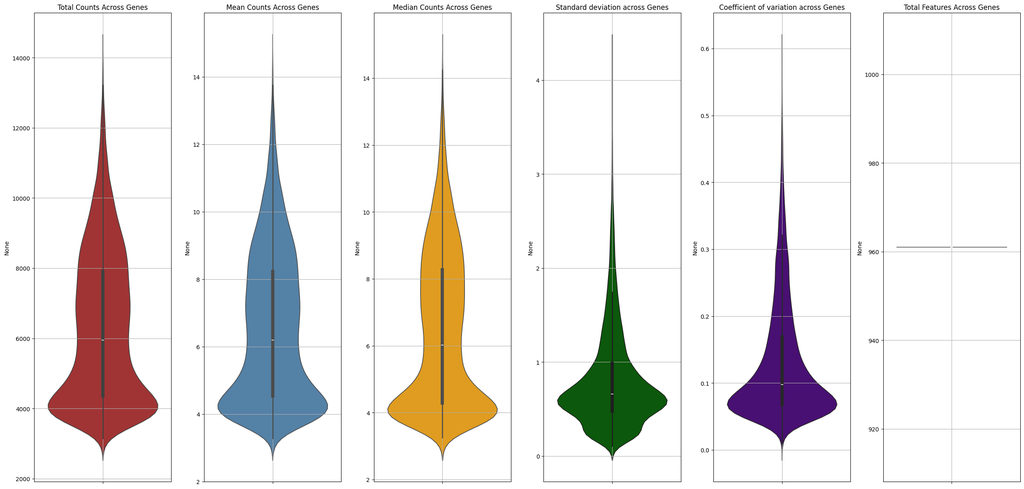

```
Max_total_count (14048.42143) - Min_total_count (3145.633516) = 10902.787914
Max_mean_count (14.61854467221644) - Min_mean_count (3.2732919001040583) = 11.345252772112381
Max_median_count (14.63556) - Min_median_count (3.254662) = 11.380898
Max std  (4.339324158207468) - Min std (0.10524694388441173) = 4.234077214323056
Max cv  (0.5959572047031719) - Min cv (0.009902479489844535) = 0.5860547252133274
Max feature count  (961) - Min feature count (961) = 0
```

```python
plot_violin_metrics(mRNA_2012,axis = 1)
```

We can see some genes are more or less constant, given the Coefficient of Variation value (CV), we should filter them. We will keep genes that are at least a CV of 5%

```python
# Filter out genes with a coefficient of variation less than 5%
cv_genes = mRNA_2012.std(axis = 1)/mRNA_2012.mean(axis = 1)
genes_to_keep = cv_genes[cv_genes > 0.05].index

# Remove
mRNA_2012 = mRNA_2012.loc[genes_to_keep]
```

Let us see how samples and genes changed after this modification.

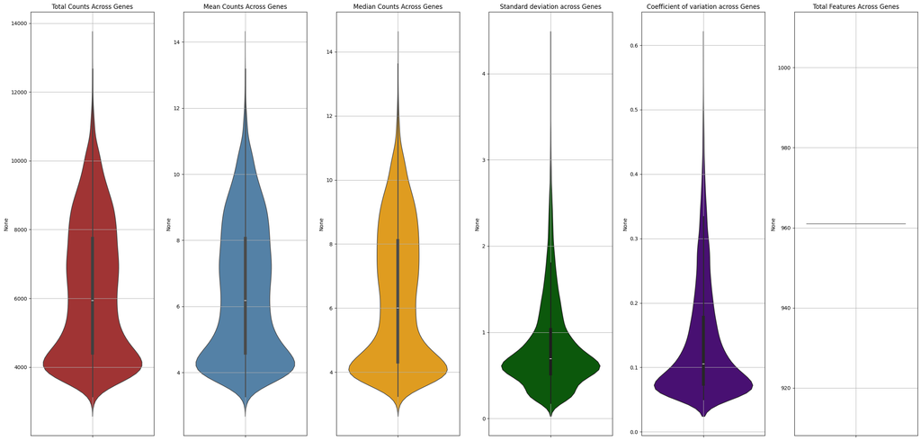

```
Max_total_count (13193.183759) - Min_total_count (3145.633516) = 10047.550243
Max_mean_count (13.728599124869927) - Min_mean_count (3.2732919001040583) = 10.455307224765868
Max_median_count (14.01119) - Min_median_count (3.254662) = 10.756528
Max std  (4.339324158207468) - Min std (0.17778478208431178) = 4.161539376123156
Max cv  (0.5959572047031719) - Min cv (0.050001968555786334) = 0.5459552361473856
Max feature count  (961) - Min feature count (961) = 0
```

```python
plot_violin_metrics(mRNA_2012,axis = 1)
```

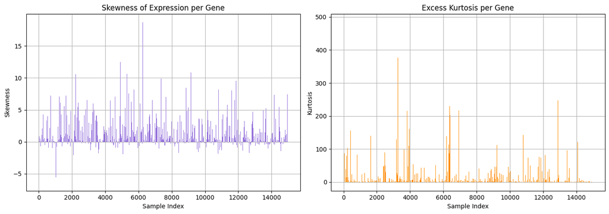

```python
plot_skewness_kurtosis(mRNA_2012,axis = 1)
```

Here we see a different trend that we observed from the samples. Genes seems mainly positive skewed as before, but some of them also negative. While, the kurtosis is always positive meaning a more pronounced peak.

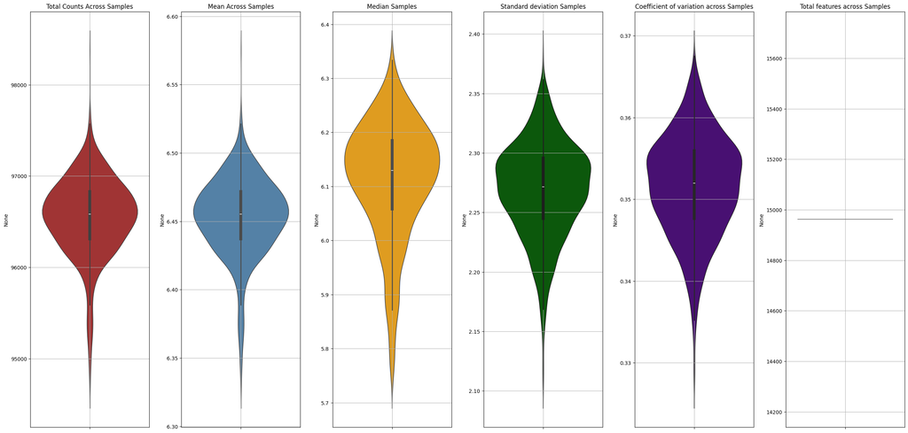

```
Max_total_count (98374.63747700027) - Min_total_count (94676.85001000023) = 3697.7874670000456
Max_mean_count (6.574965745020737) - Min_mean_count (6.327820479214024) = 0.24714526580671325
Max_median_count (6.3337125) - Min_median_count (5.744352) = 0.5893604999999997
Max_std (2.3828824383981493) - Min_std (2.1054500802500233) = 0.27743235814812595
Max CV (0.3675368169859424) - Min CV (0.3275511711022703) = 0.03998564588367215
Max feature count  (14962) - Min feature count (14962) = 0
```

```python
# See how it affected the samples
plot_violin_metrics(mRNA_2012,axis = 0)
```

After our transformation, the data seems more concentrated with no visible outliers.

### Dimensionality Reduction

We will use dimensionality reduction in order to understand if there is a good separation between mutated and non-mutated samples

```python
mRNA_2012_ordered = mRNA_2012[mutated_samples.tolist() + non_mutated_samples.tolist()]
mRNA_2012_ordered_log = np.log1p(mRNA_2012_ordered)
mRNA_2012_z_ordered = standard(mRNA_2012_ordered)
```

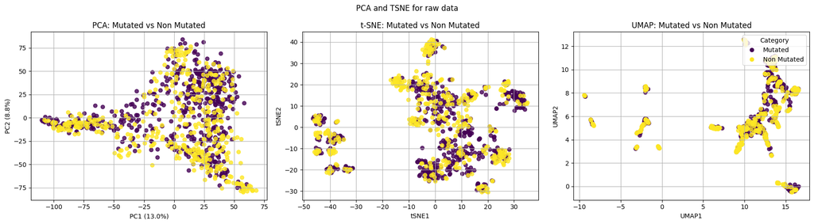

```python
plot_PCA_tsne_umap(mRNA_2012_ordered,mutated_samples,non_mutated_samples,'PCA and TSNE for raw data', categories=['Mutated','Non Mutated'])
```

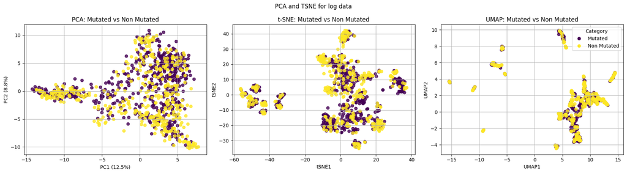

```python
plot_PCA_tsne_umap(mRNA_2012_ordered_log,mutated_samples,non_mutated_samples,'PCA and TSNE for log data', categories=['Mutated','Non Mutated'])
```

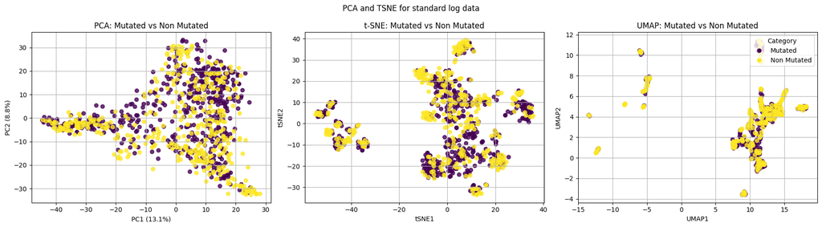

```python
plot_PCA_tsne_umap(mRNA_2012_z_ordered,mutated_samples,non_mutated_samples,'PCA and TSNE for standard log data', categories=['Mutated','Non Mutated'])
```

These plots give an idea of the separability of mutated and non mutated samples. In three different cases:

We can see that data seems not very separable in both the 3 different dimensionalty reduction techniques. Despite that, the number of dimensions is very reduced and we can hope that the data would be separable in higher dimensions. This will be assessed by classifier performance.

```python
mRNA_2012.to_csv('enrichment/CCLE_2012_filtered.csv')
```

## CCLE 2019

### Description

This CCLE dataset is made by performing the usual bulk RNA-seq technique. It was then normalized using RPKM (Reads Per Kilobase of transcript per Million) to reduce variance in order to make samples comparable.  
The RPKM normalisation solves two problems that are created during sequencing:

1. **Sequencing depth**: it occurs when samples are sequenced differently, some samples may have been sequenced more or less than others. This effect does not reflect biological status so we should correct for that.
2. **Gene Length**: the gene length tells us how easy is that gene to detect from sequencing machines. On one hand, longer genes are easier to detect, so their count will be bigger. On the other hand, smaller genes are more difficult. Normalisations on gene length take this into account.

The normalised $(i,j)$ $RPKM$ value where $i$ is a gene and $j$ is a sample: $$ \text{RPKM}_{i,j} = \frac{x_{i,j}}{l_i \cdot \sum_j x_{i,j}} 10^6 $$

Where $x_{i,j}$ is the raw count, $l_i$ is gene length in kilobases (kb), and the denominator is total reads in sample $j$.

### Data collection

```python
# ---------mRNA---------
# Description:
# Expression Data with gene as index and cells/samples as columns
mRNA_2019 = pd.read_csv('/home/3173616/ML_lab/ccle_broad_2019/data_mrna_seq_rpkm.txt',
                    sep = '\t',
                    comment = '#')
mRNA_2019.set_index('Hugo_Symbol',inplace=True)
# Merge with mean duplicated rows
mRNA_2019 = mRNA_2019.groupby(mRNA_2019.index).mean()


#--------Mut query----------
# Description:
# Data telling  which sample is mutated and not-mutated
mut_query_2019= pd.read_csv('/home/3173616/ML_lab/ccle_broad_2019/mutations_ccle_2019.txt',
                    sep = '\t',
                    comment = '#')
mut_query_2019.set_index('SAMPLE_ID',inplace=True)

# ------Mut ALL-----------
# Dataset containing mutation classes for all genes, it only contains mutated samples
mut_all_2019 = pd.read_csv('/home/3173616/ML_lab/ccle_broad_2019/data_mutations.txt',
                    sep = '\t',
                    comment = '#')
# Extract TP53 from all genes
mut_all_2019 = mut_all_2019[mut_all_2019['Hugo_Symbol'] == 'TP53']
# Remove unwanted information
mut_all_2019 = mut_all_2019[['Tumor_Sample_Barcode', 'Variant_Type']]
mut_all_2019.set_index('Tumor_Sample_Barcode', inplace=True)
# There are repetitions of my mutation type (Variant_Type)
# if there is the same sample with different Variant_Type it should be removed
variant_check = mut_all_2019.groupby(mut_all_2019.index)["Variant_Type"].nunique()

# Consistent mutations
non_consistent_indices = variant_check[variant_check != 1].index
consistent_indices = variant_check[variant_check == 1].index

# Filter
mut_all_2019 = mut_all_2019.loc[consistent_indices]
mRNA_2019 = mRNA_2019.drop(columns=[col for col in non_consistent_indices if col in mRNA_2019.columns])
mut_query_2019 = mut_query_2019.drop(index = [idx for idx in non_consistent_indices if idx in mut_query_2019.index])

# There are duplicated samples with same Variant Classification
# since it is the same sample just remove the rest and keep one
mut_all_2019 = mut_all_2019[~mut_all_2019.index.duplicated(keep='first')]
# Merged mutated samples
merged_2019 = mut_query_2019.join(mut_all_2019, how = 'left').fillna('WT')
# Free some memory
del mut_all_2019, mut_query_2019, variant_check, consistent_indices, non_consistent_indices


# Take common samples
common = list(set(mRNA_2019.columns) & set(merged_2019.index))
mRNA_2019 = mRNA_2019[common]
merged_2019 = merged_2019.loc[common]
```

```python
# Rename columns putting study id
mRNA_2019.rename(columns={i:i + '_ccle_broad_2019' for i in mRNA_2019.columns},inplace=True)
merged_2019.rename(index={i:i + '_ccle_broad_2019' for i in merged_2019.index},inplace=True)
```

### Sample filtering

```python
# Shape of mRNA
print(f'Number of genes: {len(mRNA_2019.index)}\nNumber of samples: {len(mRNA_2019.columns)}')
print(f'Zero entries: {(mRNA_2019 <= 0).sum().sum()}') # entries all positive no zeros
```

```
Number of genes: 54353
Number of samples: 1087
Zero entries: 28139836
```

Given the technique bulk mRNA, there is way more sparsity in the data

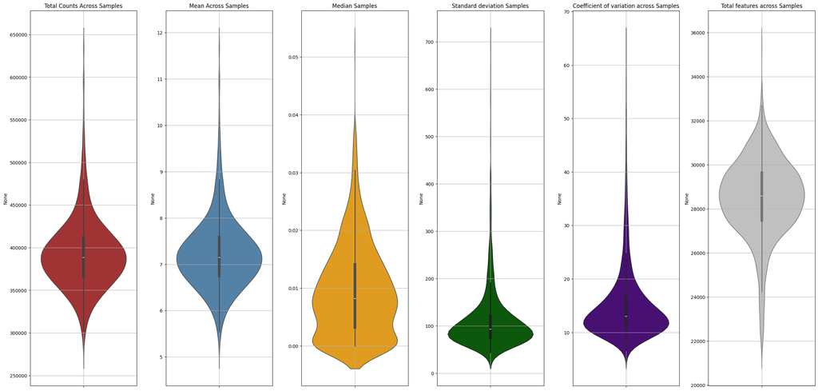

```
Max_total_count (637183.6959461462) - Min_total_count (278917.46269149065) = 358266.2332546555
Max_mean_count (11.723063969719172) - Min_mean_count (5.131592785890211) = 6.591471183828961
Max_median_count (0.05116) - Min_median_count (0.0) = 0.05116
Max_std (695.8833828039984) - Min_std (43.62939286441658) = 652.2539899395819
Max CV (63.58381480147724) - Min CV (6.623955659039273) = 56.95985914243796
Max feature count  (35339) - Min feature count (21619) = 13720
```

```python
# Plot QC metrics
plot_violin_metrics(mRNA_2019,0)
```

The quality metrics seems pretty well behaved. We can observe RPKM normalisation by the high number of counts. However, the Coefficient of Variation is pretty high for some samples so it's okay to filter for too much variated data.

```python
# Filter out genes with a coefficient of variation more than 55
cv_genes = mRNA_2019.std(axis = 0)/mRNA_2019.mean(axis = 0)
samples_to_keep = cv_genes[cv_genes < 55].index

# Filwe
mRNA_2019 = mRNA_2019[samples_to_keep]
merged_2019 = merged_2019.loc[samples_to_keep]
```

```python
corr_matrix = mRNA_2019.corr()
print('Minimum correlation between samples:',corr_matrix.describe().loc['min'].min())
print('Minimum mean correlation between samples:',corr_matrix.describe().loc['mean'].min())
```

```
Minimum correlation between samples: 0.03066116944826166
Minimum mean correlation between samples: 0.11331378318483637
```

```python
mutated_samples = merged_2019[merged_2019['Variant_Type'] != 'WT'].index
non_mutated_samples = merged_2019[merged_2019['Variant_Type'] == 'WT'].index


random_samples_mut_100 = np.random.choice(mutated_samples,size = 100)
random_samples_non_mut_100 = np.random.choice(non_mutated_samples,size = 100)
random_samples_mut_50_non_mut50 = list(random_samples_mut_100[:50]) + list(random_samples_non_mut_100[:50])
```

Let us see how the mutations are distributed

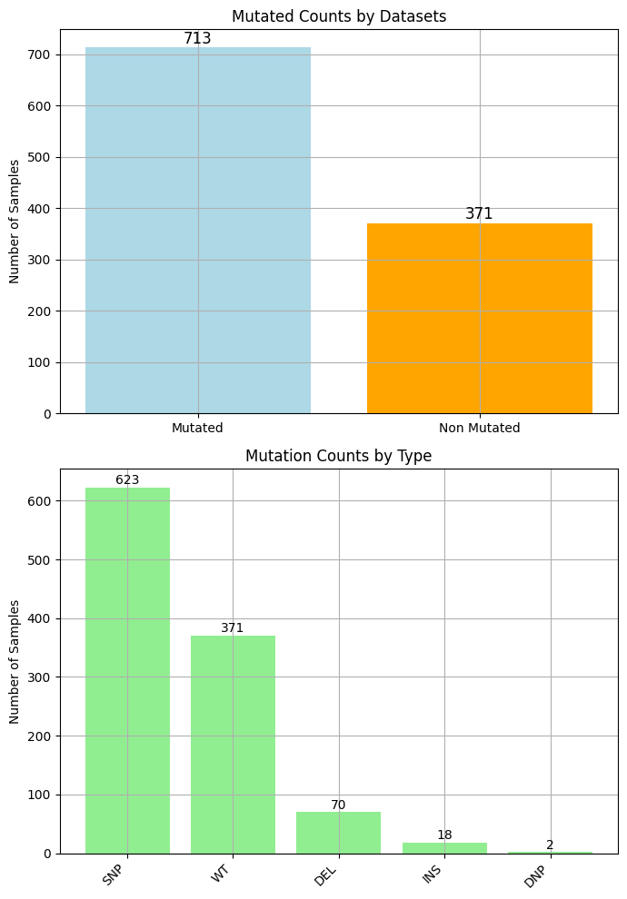

```python
# Sample counts
counts = [len(mutated_samples), len(non_mutated_samples)]

# Create subplots
fig, axs = plt.subplots(2, 1, figsize=(7, 10))

# ---- Plot 1: Sample Counts by Dataset ----
axs[0].bar(x=['Mutated', 'Non Mutated'], height=counts, color=['lightblue', 'orange'])
for i, count in enumerate(counts):
    axs[0].text(i, count + 1, str(count), ha='center', va='bottom', fontsize=12)

axs[0].set_title("Mutated Counts by Datasets")
axs[0].set_ylabel("Number of Samples")
axs[0].grid(True)

# ---- Plot 2: Mutation Counts ----
mut = merged_2019.Variant_Type.value_counts()
axs[1].bar(mut.index, mut.values, color='lightgreen')
for i, val in enumerate(mut.values):
    axs[1].text(i, val + 1, str(val), ha='center', va='bottom', fontsize=10)

axs[1].set_title("Mutation Counts by Type")
axs[1].set_ylabel("Number of Samples")
axs[1].set_xticklabels(mut.index, rotation=45, ha='right')
axs[1].grid(True)

# Adjust layout
plt.tight_layout()
plt.show()
```

Let us analyse now deeply the samples and try to see if we can find correlation in them.

```
Number of samples plotted: (100, 100)
```

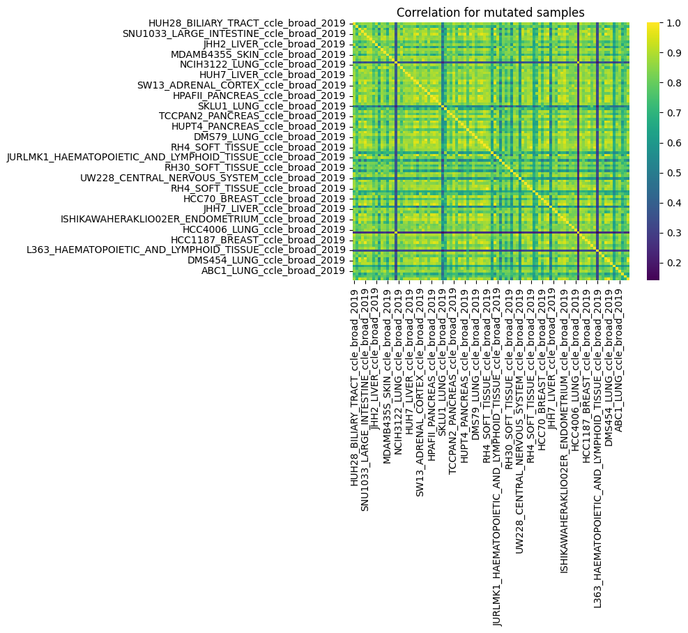

```python
heatmap_plot('Correlation for mutated samples',mRNA_2019,random_samples_mut_100)
```

```
Number of samples plotted: (100, 100)
```

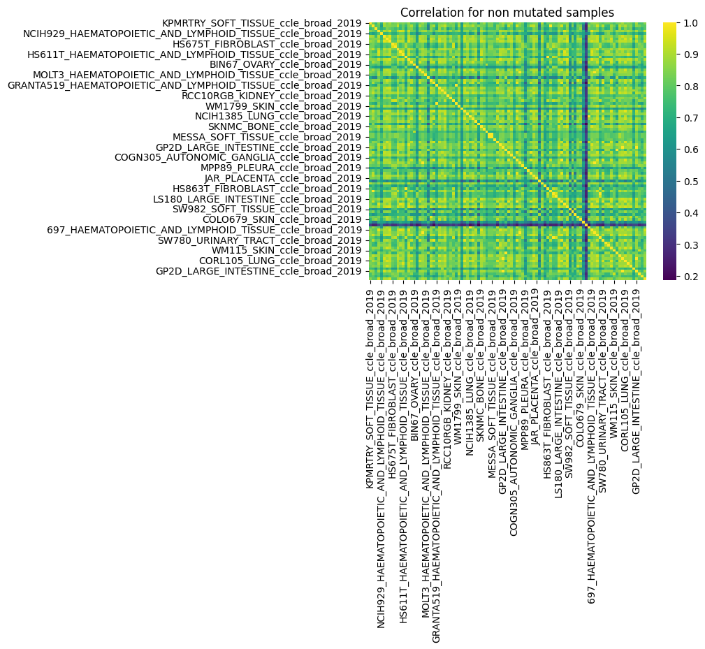

```python
heatmap_plot('Correlation for non mutated samples',mRNA_2019,random_samples_non_mut_100)
```

```
Number of samples plotted: (100, 100)
```

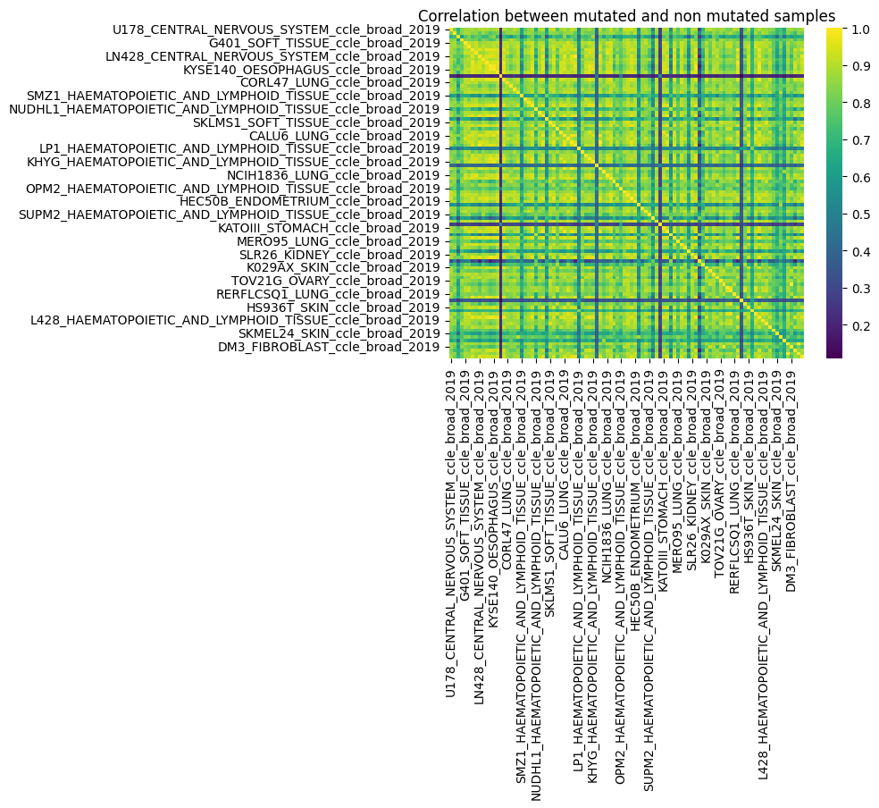

```python
heatmap_plot('Correlation between mutated and non mutated samples',mRNA_2019,random_samples_mut_50_non_mut50)
```

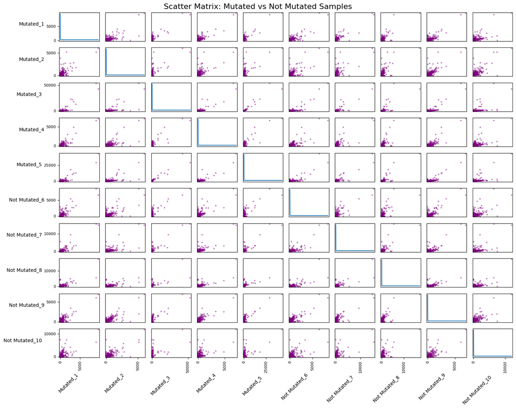

```python
sample_ids = random_samples_mut_100[:5].tolist() + random_samples_non_mut_100[:5].tolist()
sample_mut_non_mut = mRNA_2019.loc[:, sample_ids]

# Rename columns to clearer labels
new_labels = ['Mutated'] * 5 + ['Not Mutated'] * 5
sample_mut_non_mut.columns = [f"{label}_{i+1}" for i, label in enumerate(new_labels)]
axes = scatter_matrix(sample_mut_non_mut, diagonal='kde', figsize=(15, 12), color='purple')

# Rotate x and y axis labels for all subplots
for ax in axes.ravel():
    if ax is not None:
        ax.set_xlabel(ax.get_xlabel(), rotation=45, ha='right')
        ax.set_ylabel(ax.get_ylabel(), rotation=0, ha='right')

plt.suptitle("Scatter Matrix: Mutated vs Not Mutated Samples", fontsize=16)
plt.tight_layout()
plt.show()
```

```python
#-----Mutated samples-----------
print('----Mutated Samples-----')
print('1) Minimum correlation between samples:',mRNA_2019.loc[:, mutated_samples].corr().describe().loc['min'].min())
print('2) Minimum mean correlation between samples:',mRNA_2019.loc[:, mutated_samples].corr().describe().loc['mean'].min())
#----- Non Mutated samples-----------
print('----Non Mutated Samples-------')
print('1) Minimum correlation between samples:',mRNA_2019.loc[:, non_mutated_samples].corr().describe().loc['min'].min())
print('2) Minimum mean correlation between samples:',mRNA_2019.loc[:, non_mutated_samples].corr().describe().loc['mean'].min())
```

```
----Mutated Samples-----
```

[output not shown]

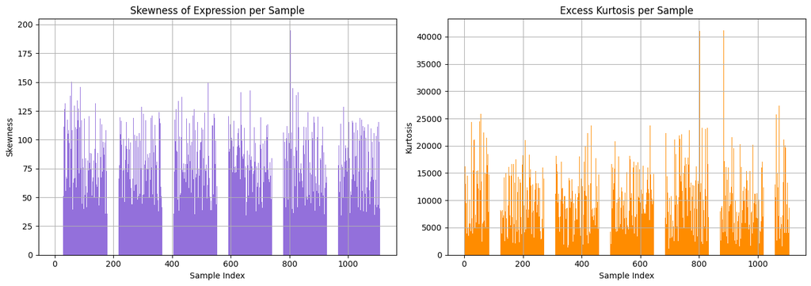

```python
plot_skewness_kurtosis(mRNA_2019,0)
```

Here both the skewness and the kurtosis are positive. Firstly, positive skewness tells that we have higher values and higher expression for genes, this is expected given the RPKM normalisation. Secondly, positive kurtosis implies more peaked distribution with fatter tails.

### Gene filtering

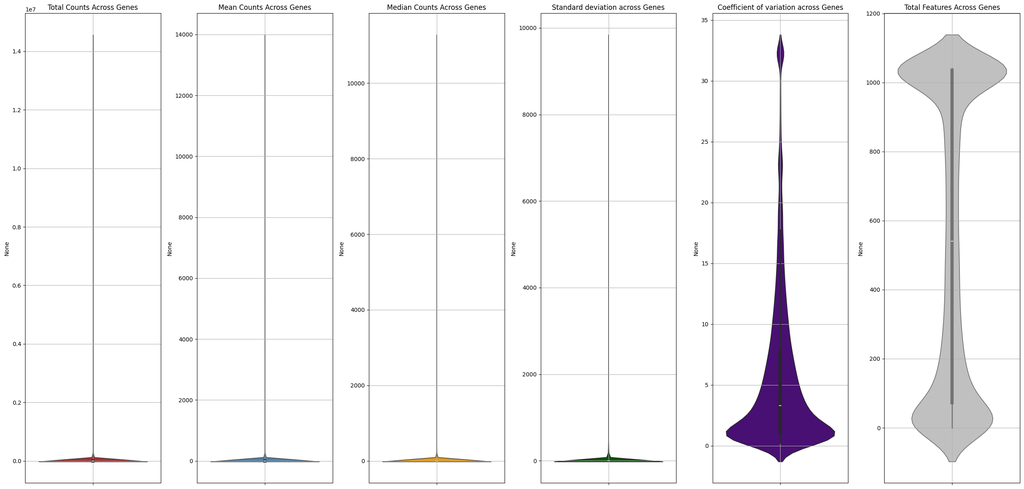

```
Max_total_count (14546996.81527) - Min_total_count (0.0) = 14546996.81527
Max_mean_count (13974.060341277616) - Min_mean_count (0.0) = 13974.060341277616
Max_median_count (11267.23926) - Min_median_count (0.0) = 11267.23926
Max std  (9825.42742570475) - Min std (0.0) = 9825.42742570475
Max cv  (32.26453160980483) - Min cv (0.23559975120303178) = 32.028931858601794
Max feature count  (1041) - Min feature count (0) = 1041
```

```python
plot_violin_metrics(mRNA_2019,1)
```

The QC matrix tells us that there are very peaked genes, but the reason is that there are many zero count genes. Our aim is to reduce variation, so we will remove them

```python
threshold = mRNA_2019.shape[1]*(0.1)
genes_to_keep = mRNA_2019.astype(bool).sum(axis=1)[mRNA_2019.astype(bool).sum(axis=1) > threshold].index
mRNA_2019 = mRNA_2019.loc[genes_to_keep]
```

Let us see how genes and sample distribution change after this filtering

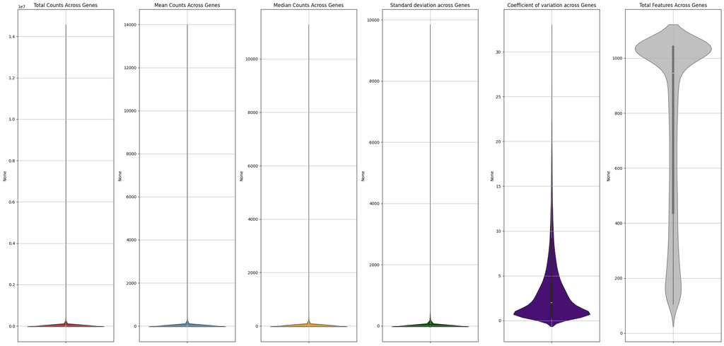

```
Max_total_count (14546996.81527) - Min_total_count (0.49056999999999995) = 14546996.3247
Max_mean_count (13974.060341277616) - Min_mean_count (0.00047124879923150814) = 13974.059870028817
Max_median_count (11267.23926) - Min_median_count (0.0) = 11267.23926
Max std  (9825.42742570475) - Min std (0.0015102986130363179) = 9825.425915406136
Max cv  (32.151431074863886) - Min cv (0.23559975120303178) = 31.915831323660854
Max feature count  (1041) - Min feature count (105) = 936
```

```python
plot_violin_metrics(mRNA_2019,1)
```

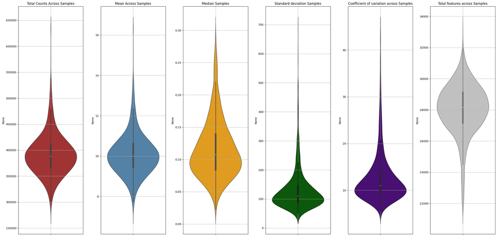

```
Max_total_count (636370.4791678139) - Min_total_count (278803.2365964906) = 357567.2425713233
Max_mean_count (16.37766314514654) - Min_mean_count (7.175294332831238) = 9.2023688123153
Max_median_count (0.29837) - Min_median_count (0.02308) = 0.27529000000000003
Max_std (690.4132730591268) - Min_std (51.36637360316444) = 639.0468994559624
Max CV (44.38441069424621) - Min CV (5.576373512416535) = 38.808037181829675
Max feature count  (33161) - Min feature count (21508) = 11653
```

```python
plot_violin_metrics(mRNA_2019,0)
```

### Dimensionality Reduction

```python
mRNA_2019_ordered = mRNA_2019[mutated_samples.tolist() + non_mutated_samples.tolist()]
mRNA_2019_ordered_log = np.log1p(mRNA_2019_ordered)
mRNA_2019_scaled = standard(mRNA_2019_ordered_log)
```

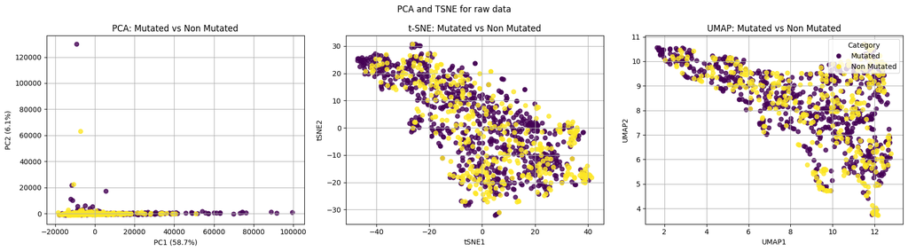

```python
plot_PCA_tsne_umap(mRNA_2019_ordered,mutated_samples,non_mutated_samples,'PCA and TSNE for raw data', categories=['Mutated','Non Mutated'])
```

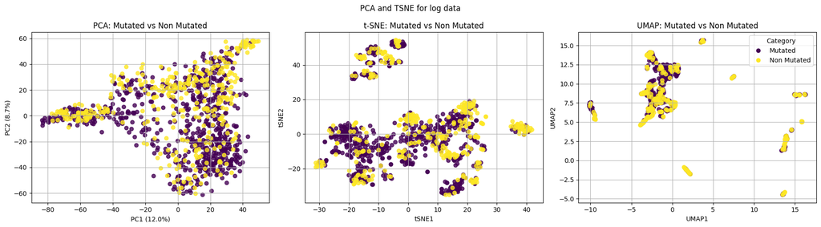

```python
plot_PCA_tsne_umap(mRNA_2019_ordered_log,mutated_samples,non_mutated_samples,'PCA and TSNE for log data', categories=['Mutated','Non Mutated'])
```

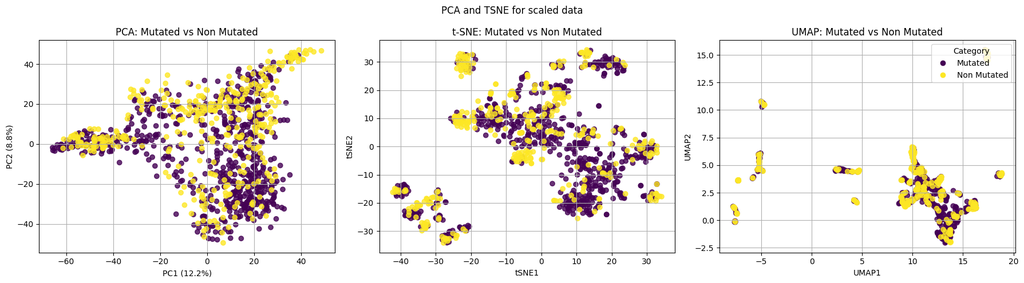

```python
plot_PCA_tsne_umap(mRNA_2019_scaled,mutated_samples,non_mutated_samples,'PCA and TSNE for scaled data', categories=['Mutated','Non Mutated'])
```

These plots give an idea of the separability of mutated and non mutated samples. In three different cases:

1. Raw bulk RNAseq data
2. Log transformed (log(1+x)) bulk RNAseq data
3. Standard log transformed bulk RNAseq data

We can see that data seems not very separable in both the 3 different dimensionalty reduction techniques. Despite that, the number of dimensions is very reduced and we can hope that the data would be separable in higher dimensions. This will be assessed by classifier performance.

```python
mRNA_2019.to_csv('enrichment/CCLE_2019_filtered.csv')
```

## Merged Cell Lines

Next, we will assess the presence of batch effects and correct them if necessary.

### Intersection

Here we merge the two datasets and take the common genes only.

```python
# Create datasets
intersection = list(set(mRNA_2012.index) & set(mRNA_2019.index))
m_RNA_2012_int = mRNA_2012.loc[intersection]
m_RNA_2019_int = mRNA_2019.loc[intersection]
```

```python
# Merge mutation data
merged_2012 = merged_2012.loc[m_RNA_2012_int.columns]
merged_2019 = merged_2019.loc[m_RNA_2019_int.columns]
Mut_combined  = pd.concat([merged_2012,merged_2019])
```

```python
# Merge expression data
mRNA_final_int = pd.concat([m_RNA_2012_int,m_RNA_2019_int],axis = 1)
# Log transform to reduce scale and then standardize to make both data comparable
mRNA_final_int = standard(np.log1p(mRNA_final_int))
```

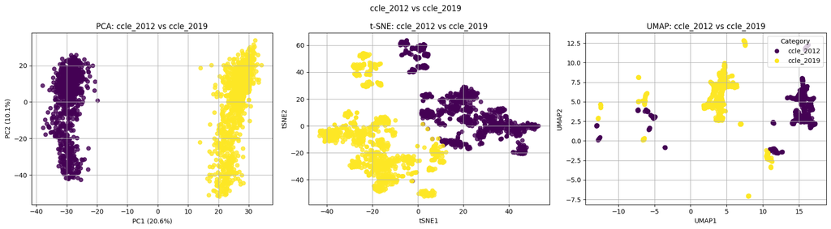

```python
plot_PCA_tsne_umap(mRNA_final_int,m_RNA_2012_int.columns,m_RNA_2019_int.columns, 'ccle_2012 vs ccle_2019',categories = ['ccle_2012','ccle_2019'])
```

This plot let us see exactly the difference between these two sequencing techniques, and the batch effect is clearly seen. Now we should understand how to correct it.

In order to correct it we will use the well established pyCombat library [4].

The Combat framework fits a gene-wise location/scale model. For each gene **g** in sample **j** from batch **i**, the observed (transformed) expression $Y_{ijg}$ is said to follow: $$ Y_{ijg} = \alpha_g + X_{ij}\beta_{g} + \gamma_{ig} + \delta_{ig}\epsilon_{ijk} $$ Where:

1. $\alpha_g$: overall gene expression;
2. $X_{ij}$: design matrix (known biological covariates);
3. $\beta_g$: vector of regression;
4. $\gamma_{ig}$: additive batch effect for batch i on gene g;
5. $\delta_{ig}$: multiplicative batch effect for batch i on gene g;
6. $\epsilon_{ijk}$: normal distributed error term;

Because individual batches often have few samples, ComBat borrows strength across genes by placing hierarchical (Bayesian) priors on the batch-effect parameters $\gamma_{ig}$ and $\delta_{ig}$:

1. $\gamma_{ig}$ ~ $N[\gamma_i, \tau_i^2]$
2. $\delta_{ig}$ ~ Inverse-Gamma($\alpha_i$,$\beta_i$)

The combat batch correction divides into 3 steps:

1. Standardize data (gene-wise);
2. Estimate batch effect (all the parameters of the location/scale model) via **Empirical Bayes (EB)**;
3. Adjust the data with estimated parameters

To avoid introducing bias, we cannot apply batch correction to the entire dataset at once, as this would allow information from the test set to influence the training set. Instead, we perform batch correction separately on the training and test sets to maintain a separation between them.

```python
X = mRNA_final_int
y = Mut_combined.Variant_Type
```

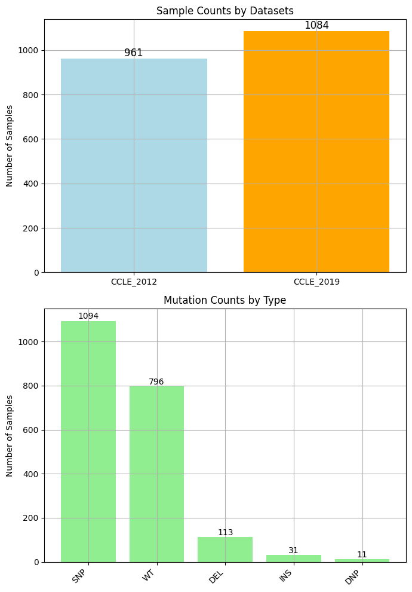

```python
# Sample counts
counts = [len(m_RNA_2012_int.columns), len(m_RNA_2019_int.columns)]

# Create subplots
fig, axs = plt.subplots(2, 1, figsize=(7, 10))

# ---- Plot 1: Sample Counts by Dataset ----
axs[0].bar(x=['CCLE_2012', 'CCLE_2019'], height=counts, color=['lightblue', 'orange'])
for i, count in enumerate(counts):
    axs[0].text(i, count + 1, str(count), ha='center', va='bottom', fontsize=12)

axs[0].set_title("Sample Counts by Datasets")
axs[0].set_ylabel("Number of Samples")
axs[0].grid(True)

# ---- Plot 2: Mutation Counts ----
mut = y.value_counts()
axs[1].bar(mut.index, mut.values, color='lightgreen')
for i, val in enumerate(mut.values):
    axs[1].text(i, val + 1, str(val), ha='center', va='bottom', fontsize=10)

axs[1].set_title("Mutation Counts by Type")
axs[1].set_ylabel("Number of Samples")
axs[1].set_xticklabels(mut.index, rotation=45, ha='right')
axs[1].grid(True)

# Adjust layout
plt.tight_layout()
plt.show()
```

The two datasets seem balanced by the number of sampls but clearly not by the type of mutation

```python
X_train, X_test, y_train, y_test = train_test_split(
    X.T, y,
    test_size=0.2,
    stratify=y,
    random_state=42
)
X_train = X_train.T
X_test = X_test.T
```

```python
samples_train_2019 = [col for col in X_train.columns if col[-1] == '9']
samples_train_2012 = [col for col in X_train.columns if col[-1] == 'd']

samples_test_2019 = [col for col in X_test.columns if col[-1] == '9']
samples_test_2012 = [col for col in X_test.columns if col[-1] == 'd']

X_train, y_train = X_train[samples_train_2019 + samples_train_2012], y_train[samples_train_2019 + samples_train_2012]
X_test, y_test = X_test[samples_test_2019 + samples_test_2012], y_test[samples_test_2019 + samples_test_2012]
```

```python
print("Train:",X_train.shape)
print("Test:",X_test.shape)
```

```
Train: (13867, 1636)
Test: (13867, 409)
```

Now let us batch correct

```python
batch_train = ['mRNA']*len(samples_train_2019) + ['micro']*len(samples_train_2012)
print(X_train.shape, len(batch_train))
X_train = pycombat(X_train, batch_train)

batch_test = ['mRNA']*len(samples_test_2019) + ['micro']*len(samples_test_2012)
print(X_test.shape, len(batch_test))
X_test = pycombat(X_test, batch_test)
```

```
(13867, 1636) 1636
Found 2 batches.
Adjusting for 0 covariate(s) or covariate level(s).
Standardizing Data across genes.
Fitting L/S model and finding priors.
Finding parametric adjustments.
Adjusting the Data
(13867, 409) 409
Found 2 batches.
Adjusting for 0 covariate(s) or covariate level(s).
Standardizing Data across genes.
Fitting L/S model and finding priors.
Finding parametric adjustments.
Adjusting the Data
```

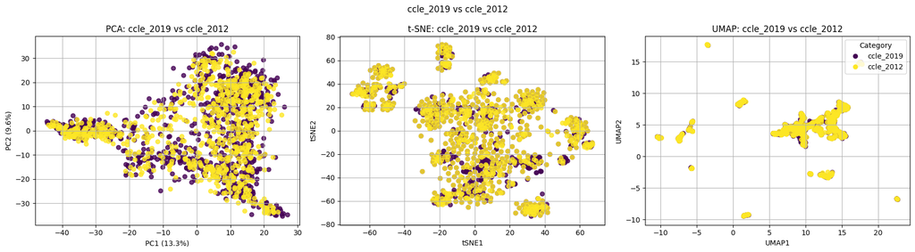

```python
plot_PCA_tsne_umap(X_train,samples_train_2019,samples_train_2012, 'ccle_2019 vs ccle_2012',categories = ['ccle_2019','ccle_2012'])
```

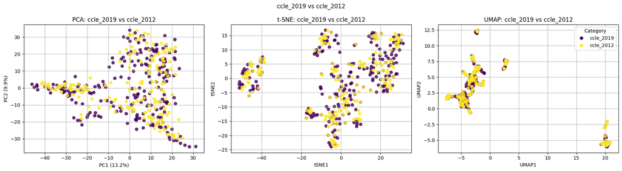

```python
plot_PCA_tsne_umap(X_test,samples_test_2019,samples_test_2012, 'ccle_2019 vs ccle_2012',categories = ['ccle_2019','ccle_2012'])
```